# Does a Flood Map Transfer to a New Flood?

- Show All Code
- Hide All Code
- View Source

Five water-mapping methods, eleven floods, and what changes from one flood to the next

Author

Published

October 8, 2026

**Interactive application**

[Open the Streamlit app](https://flood-radar-analytics-bg6uugifczndcbtsrps6cd.streamlit.app/)

## 1 Introduction

Floods arrive with storm clouds, which blind ordinary (optical) satellites. **Synthetic-aperture radar** isn’t blind: Sentinel-1 sends its own microwave pulse, day or night, through cloud. Calm water reflects that pulse away from the satellite like a mirror, so it appears **dark**; rough land scatters some back.

## 2 Data

**Sen1Floods11** (Bonafilia et al., CVPR Workshops 2020): 446 hand-labelled 512×512-pixel chips (~10 m pixels) from 11 flood events — Bolivia, Ghana, India, Mekong, Nigeria, Pakistan, Paraguay, Somalia, Spain, Sri Lanka, USA. Each chip has Sentinel-1 radar (VV and VH, in dB), Sentinel-2 optical bands from the same period (often partly cloudy), a hand label (water / not water), and the JRC permanent-water mask, which separates rivers and lakes from new floodwater.

## 3 Methods

| Method | What it uses |
| --- | --- |
| VV threshold | Water where VV is below one dB value, fit on the training floods |
| Authors’ Otsu | The dataset authors’ per-scene Otsu threshold — adapts to each scene, no training |
| LightGBM | Gradient-boosted trees on each pixel’s VV, VH, their ratio, and neighbourhood mean / spread at 50 m and 150 m |
| U-Net (radar) | Convolutional segmentation network (ResNet-34 encoder) on VV, VH and their ratio |
| U-Net (radar + optical) | The same network with six Sentinel-2 bands and the NDWI water index added |

Two evaluations:

1. **Official split** — the dataset’s own train / validation / test chips (drawn from the same 10 floods) plus Bolivia, held out entirely.
2. **Leave-one-event-out** — for each of the 11 floods: train on the other 10, score on that one. The U-Net chooses its best epoch on 10% of the *training* chips, never the held-out flood.

Metric: **water IoU** (intersection over union), pooled over all valid pixels.

## 4 Results

### 4.1 On familiar floods, complexity pays

|  | test | Bolivia (unseen) |
| --- | --- | --- |
| VV threshold | 0.464 | 0.441 |
| Authors' Otsu | 0.554 | 0.718 |
| LightGBM (radar + texture) | 0.637 | 0.405 |
| U-Net (radar) | 0.672 | 0.597 |
| U-Net (radar + optical) | 0.830 | 0.811 |

On the official test split — chips from floods the models trained on — each step up in complexity helps, and adding optical bands helps most.

### 4.2 On a new flood, the picture changes

| event | Threshold | Otsu | LightGBM | U-Net radar | U-Net radar+optical |
| --- | --- | --- | --- | --- | --- |
| Somalia | 0.15 | 0.15 | 0.22 | 0.27 | 0.70 |
| Paraguay | 0.43 | 0.45 | 0.55 | 0.53 | 0.60 |
| Pakistan | 0.24 | 0.15 | 0.30 | 0.32 | 0.65 |
| Sri-Lanka | 0.16 | 0.65 | 0.59 | 0.68 | 0.85 |
| Ghana | 0.35 | 0.41 | 0.39 | 0.49 | 0.68 |
| USA | 0.29 | 0.51 | 0.51 | 0.50 | 0.78 |
| Nigeria | 0.55 | 0.64 | 0.65 | 0.76 | 0.89 |
| India | 0.47 | 0.53 | 0.51 | 0.53 | 0.71 |
| Spain | 0.63 | 0.67 | 0.72 | 0.56 | 0.85 |
| Bolivia | 0.44 | 0.72 | 0.43 | 0.68 | 0.81 |
| Mekong | 0.77 | 0.78 | 0.83 | 0.84 | 0.92 |
| Pooled | 0.43 | 0.50 | 0.57 | 0.59 | 0.78 |

Pooled over all 11 held-out floods, **U-Net (radar + optical)** scores best (IoU 0.78). Compared with the official test split (familiar floods): VV threshold drops 0.03, Authors’ Otsu drops 0.06, LightGBM (radar + texture) drops 0.07, U-Net (radar) drops 0.08, U-Net (radar + optical) drops 0.05. The radar + optical U-Net is the best method on 11 of 11 held-out floods.

### 4.3 Why fixed rules break: the right threshold moves

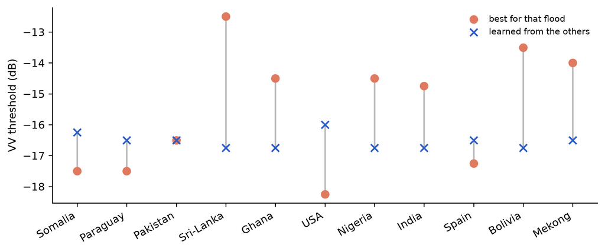

Each flood’s own best VV threshold (dots) against the threshold learned from the other ten floods (crosses).

```python
fig, ax = plt.subplots(figsize=(8, 3.4))
x = np.arange(len(order))
ax.scatter(x, [oracle[e] for e in order], color="#e07a5f", s=50, zorder=3, label="best for that flood")
ax.scatter(x, [learned[e] for e in order], color="#2c5cc5", marker="x", s=50, zorder=3, label="learned from the others")
for i, e in enumerate(order):
    ax.plot([i, i], [oracle[e], learned[e]], color="#bbb", zorder=1)
ax.set_xticks(x, order, rotation=30, ha="right"); ax.set_ylabel("VV threshold (dB)")
ax.legend(frameon=False, fontsize=8); plt.tight_layout(); plt.show()
```

Each flood’s own best threshold ranges from **-18.25 to -12.50 dB** (5.8 dB). Any threshold learned from the other floods lands between -16.75 and -16.00 dB — essentially one number. The worst mismatch is **Sri-Lanka**: its best threshold is -12.50 dB against a learned -16.75 dB, and the fixed threshold scores IoU 0.16 there while per-scene Otsu scores 0.65.

### 4.4 For radar alone, the flood matters more than the method

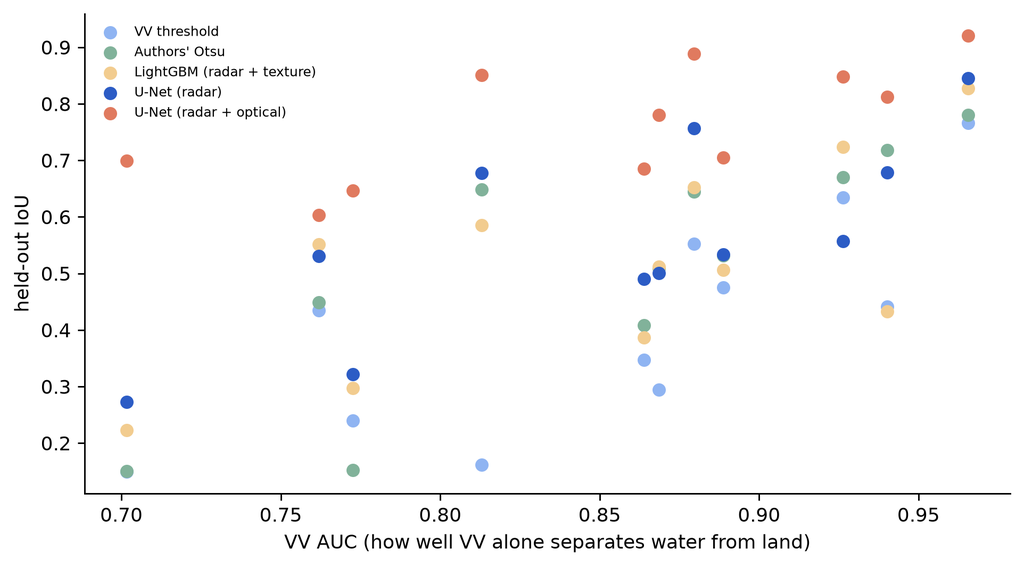

Held-out IoU against how separable water is in that flood’s radar (VV AUC).

```python
fig, ax = plt.subplots(figsize=(7.5, 4.2))
for m in held_out.columns:
    ax.scatter(sep.loc[held_out.index, "vv_auc"], held_out[m], s=35, color=COLORS[m], label=m)
ax.set_xlabel("VV AUC (how well VV alone separates water from land)"); ax.set_ylabel("held-out IoU")
ax.legend(frameon=False, fontsize=7); plt.tight_layout(); plt.show()
corr = {m: held_out[m].corr(sep.loc[held_out.index, "vv_auc"]) for m in held_out.columns}
```

How visible water is to radar varies enormously: in **Somalia** water is only 2.6 dB darker than land (AUC 0.70); in **Mekong**, 12.0 dB (AUC 0.97). Every method’s score tracks this closely (correlations VV threshold 0.77, Authors’ Otsu 0.84, LightGBM (radar + texture) 0.68, U-Net (radar) 0.75, U-Net (radar + optical) 0.68).

For the radar-only methods, a method’s IoU varies by **0.61** on average from one flood to another, while different methods on the same flood differ by only **0.19**: which flood you’re mapping predicts the result better than which radar method you use. Adding optical bands changes that: the radar + optical U-Net’s scores span only 0.32 across floods, and its biggest gains come exactly on the floods where radar struggles most (e.g. Somalia: radar-only best 0.27, radar + optical 0.70).

4.5 Where water is missed

Recall (share of labelled water found) on held-out floods, for permanent water (rivers, lakes) and new floodwater:

|  | new floodwater | permanent water |
| --- | --- | --- |
| VV threshold | 0.45 | 0.75 |
| Authors' Otsu | 0.60 | 0.99 |
| LightGBM (radar + texture) | 0.52 | 0.94 |
| U-Net (radar) | 0.62 | 0.91 |
| U-Net (radar + optical) | 0.81 | 0.99 |

Split by vegetation (NDVI from clear-sky Sentinel-2 pixels), the best model’s recall collapses as vegetation increases — water among or under plants is close to invisible. Labelled water is rare in vegetated pixels, so these are small samples:

| ndvi | water share | recall | false-alarm rate |
| --- | --- | --- | --- |
| bare / water (< 0.2) | 0.639 | 0.91 | 0.0845 |
| sparse (0.2-0.4) | 0.019 | 0.24 | 0.0283 |
| moderate (0.4-0.6) | 0.004 | 0.05 | 0.0021 |
| dense (> 0.6) | 0.002 | 0.01 | 0.0002 |

## 5 Limitations

- **Eleven floods is a small sample** for statements about “a new flood”; per-flood scores rest on 15 to 69 chips each, and some floods have little water.
- **Optical data needs clear skies.** The radar + optical model was trained and tested on chips whose Sentinel-2 image is sometimes partly cloudy, but how it behaves under complete cloud cover wasn’t tested separately — and real flood response often has no cloud-free optical image at all.
- **Hand labels have their own uncertainty**, especially at shorelines and in flooded vegetation.
- **One processing chain.** All radar here was processed identically; mixing radar products from different pipelines can shift values by several dB and break models silently.

## 6 Conclusion

On familiar floods, more complex models win clearly. On a new flood, every method loses ground, and for radar-only methods the result depends more on the flood than on the method: the brightness of water in radar shifts by several dB between floods, so any single learned threshold is wrong somewhere, and a per-scene method like Otsu beats it exactly on those floods. Among radar-only methods, **U-Net (radar)** transfers best (pooled IoU 0.59). Adding optical bands gives the strongest model overall (pooled IoU 0.78) — with the caveat that real flood response often has no cloud-free optical image, when only the radar results apply.